# 2020 Census response rates API

Bernardo Lopez Vicencio, [NewsCounts](https://newscounts.org/)

The Census Bureau, starting on March 20, has been releasing daily data of the [2020 Census response rates](https://2020census.gov/en/response-rates.html) through a well documented [API](https://www.census.gov/data/developers/data-sets/decennial-response-rates.html). In NewsCounts we have been keeping track of these daily data and now we have it available for everyone who wants to use it through our own API.

Our API offers daily snapshots of the response rates, as opposed to the cumulative data that the Bureau’s API provides. Also our API gives the ability of retrieving data in JSON format, CSV files that can be opened in Excel, and it can create automated plots of the response rates.

## Use examples

Downloading the data is as simple as going to a specific URL in your favorite web browser. For example, to get the response rates for all states go to:

```
https://newscounts.appspot.com/api/response_rates/state?FORMAT=CSV
```

- Counties with higher response rate

| county_name | CRRALL |
| --- | --- |
| Niagara | 37.8 |
| Onondaga | 37.4 |
| Erie | 37.3 |
| Tioga | 36.5 |
| Monroe | 36.4 |

- Counties with low response rate

| county_name | CRRALL |
| --- | --- |
| Hamilton | 1.4 |
| Sullivan | 12.5 |
| Essex | 15.3 |
| Delaware | 16.4 |
| Greene | 16.9 |

By having the daily data we can do more interesting things, such as time series to look for trends in the response rates. We have included a function in the API that gives you automatic time series plots. For this example, by using the following URL, I can get a plot that compares the cumulative response rate for the states of California, New York, Pennsylvania and Alaska.

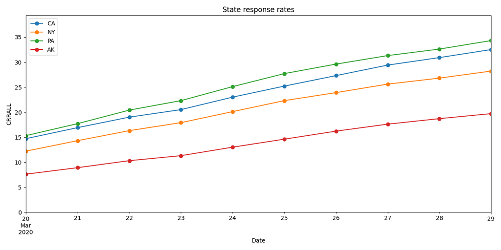

Example automatic plot.

```r
image_url <- "https://newscounts.appspot.com/api/response_rates/state?FORMAT=PNG&DATA=CRRALL&STATE=CA,NY,PA,AK"
```

As days pass by, we can look to more interesting trends not just for the state level, but also for counties and tracts.

## Documentation

### State data

**Method:** GET

**URL:** `https://newscounts.appspot.com/api/response_rates/state`

**Response format:** CSV and JSON for data, PNG for plot image.

**Parameters:**

[output not shown]

**Example request:**

```
https://newscounts.appspot.com/api/response_rates/state?FORMAT=JSON&DATA=CRRALL,DRRALL&STATE=NY&FROM=2020-03-23&TO=2020-03-25
```

**Example response:**

```
{"CRRALL":22.3,"DRRALL":2.2,"GEO_ID":"0400000US36","RESP_DATE":"2020-03-25","state":36,"state_name":"New York","state_short":"NY"},
{"CRRALL":20.1,"DRRALL":2.2,"GEO_ID":"0400000US36","RESP_DATE":"2020-03-24","state":36,"state_name":"New York","state_short":"NY"},
{"CRRALL":17.9,"DRRALL":1.5,"GEO_ID":"0400000US36","RESP_DATE":"2020-03-23","state":36,"state_name":"New York","state_short":"NY"}
```

### County data

**Method:** GET

**URL:** `https://newscounts.appspot.com/api/response_rates/county`

**Response format:** CSV and JSON for data, PNG for plot image.

**Parameters:**

[output not shown]

**Example request:**

```
https://newscounts.appspot.com/api/response_rates/county?FORMAT=JSON&DATA=CRRALL,DRRALL&STATE=NY&COUNTY=3&FROM=2020-03-23&TO=2020-03-25
```

**Example response:**

```
{"CRRALL":19.6,"DRRALL":1.5,"GEO_ID":"0500000US36003","RESP_DATE":"2020-03-25","county":"003","county_name":"Allegany","state":36,"state_name":"New York","state_short":"NY"},
{"CRRALL":18.1,"DRRALL":1.0,"GEO_ID":"0500000US36003","RESP_DATE":"2020-03-24","county":"003","county_name":"Allegany","state":36,"state_name":"New York","state_short":"NY"},
{"CRRALL":17.1,"DRRALL":0.5,"GEO_ID":"0500000US36003","RESP_DATE":"2020-03-23","county":"003","county_name":"Allegany","state":36,"state_name":"New York","state_short":"NY"}
```

### Tract data

**Method:** GET

**URL:** `https://newscounts.appspot.com/api/response_rates/tract`

**Response format:** CSV and JSON for data, PNG for plot image.

**Parameters:**

[output not shown]

**Example request:**

```
https://newscounts.appspot.com/api/response_rates/tract?FORMAT=JSON&DATA=CRRALL,DRRALL&STATE=NY&COUNTY=3&FROM=2020-03-25&TO=2020-03-25&TRACT=950600
```

**Example response:**

```
{"CRRALL":24.9,"DRRALL":2.2,"GEO_ID":"1400000US36003950600","RESP_DATE":"2020-03-25","county":"003","county_name":"Allegany","state":36,"state_name":"New York","state_short":"NY","tract":"950600"}
```

## DATA labels definition

- **CRRALL:** Cumulative Self-Response Rate - Overall
- **CRRINT:** Cumulative Self-Response Rate - Internet
- **DAVG:** Average Daily Overall Self-Response Rate
- **DINTAVG:** Average Daily Internet Self-Response Rate
- **DRRALL:** Daily Self-Response Rate - Overall
- **DRRINT:** Daily Self-Response Rate - Internet